# Python for Chemists

2022-11-03

Kiyoto Aramis Tanemura\ Diego Sierra Costa\ Kenneth M. Merz Jr.

# Python for Chemists

1. Big Data and Chemistry
- Lessons from the Omics Revolution
- Chemistry as a Big Data Science
- The Fourth Paradigm of Science: Data Science
2. Why Begin Coding in Python
- Guiding Principles of Python
- Utilize Python Libraries
- Simple and Concise
3. About *Python for Chemists*
- Motivation and Goals
- Chapter by Chapter

[figure not shown]

# What the Omics Revolution Signified for Biological Sciences

| **Human Genome Project** | **The Molecular Tree of Life** | **Protein BLAST** |
| --- | --- | --- |
| Collins, F. S.; Morgan, M.; Patrinos, A. "The Human Genome Project: Lessons from Large-Scale Biology" *Science* **2003**, *300*, 286. | Woese, C. R.; Kandler, O.; Wheelis, M. L. "Towards a natural system of organisms: Proposal for the domains Archea, Bacteria, and Eucarya" *Proc. Natl. Acad. Sci. USA* **1990**, *87*, 4576. | Altschul, S. F.; Gish, W.; Miller, W.; Myers, E. W.; Lipman, D. J. "Basic Local Alignment Search Tool" *J. Mol. Biol.* **1990**, *215*, 403. |

# Computation in the Biological Sciences

"Pipette biologist. Microscopy biologist. Cell culture biologist. Have you ever heard any of those job titles? No, of course not. All are biologists, because it is the questions you address that matter, not the tools you use, and computational biologists are just biologists using a different tool."

Markowetz, F. "All biology is computational biology" *PLoS Biol.* **2017**, *15*, e2002050.

# Chemistry as a Big Data Science

| **Retrosynthesis/Reaction Prediction** | **High Throughput Screening** | **Natural Product Identification** |
| --- | --- | --- |
| Wołos, A.; Roszak, R.; Żadło-Dobrowolska, A.; Beker, W.; Mikulak-Klucznik, B.; Spólnik, G.; Dygas, M.; Szymkuć, S.; Grzybowski, B. A. "Synthetic connectivity, emergence, and self-regeneration in the n… | Pyzer-Knapp, E. O.; Suh, C.; Gómez-Bombarelli, R.; Aguilera-Iparraguirre, J.; Aspuru-Guzik, A. "What Is High-Throughput Virtual Screening? A Perspective from Organic Materials Discovery" *Ann. Rev. Ma… | Hufsky, F.; Scheubert, K.; Böcker, S. "New kids on the block: novel informatics methods for natural product discovery" *Nat. Prod. Rep.* **2014**, *31*, 807. |

# Coding Is the Chemists Entry to Data Science

[figure not shown]

https://data.library.arizona.edu/file/166

# The Fourth Paradigm of Science

[figure not shown]

Schleder, G. R.; Padilha, A. C. M; Acosta, C. M.; Costa, M.; Fazzio, A. *J. Phys. Mater.* **2019**, *2*, 032001

# Guiding Principles of Python

Van Rossum, G.; Drake, F. L. *Python 3 Reference Manual*. **2009** Scotts Valley, CA: CreateSpace.

```python
import this
```

```
The Zen of Python, by Tim Peters

Beautiful is better than ugly.
Explicit is better than implicit.
Simple is better than complex.
Complex is better than complicated.
Flat is better than nested.
Sparse is better than dense.
Readability counts.
Special cases aren't special enough to break the rules.
Although practicality beats purity.
Errors should never pass silently.
Unless explicitly silenced.
In the face of ambiguity, refuse the temptation to guess.
There should be one-- and preferably only one --obvious way to do it.
Although that way may not be obvious at first unless you're Dutch.
Now is better than never.
Although never is often better than *right* now.
If the implementation is hard to explain, it's a bad idea.
If the implementation is easy to explain, it may be a good idea.
Namespaces are one honking great idea -- let's do more of those!
```

# Code Can Be Reused by Importing Python Modules

```python
# A Tris-HCl buffer was prepared by dissolving 60.6 g Tris base and 78.7 g Tris-HCl salt in water to a final
# volume of 1 L. Calculate the pH  at 25 degrees Celcius.
m_base = 60.6 # g
m_salt = 78.7 # g
vol_f = 1 # L

pKa = 8.07
mw_base = 121.136 # g / mol
mw_salt = 157.59694 # g / mol
```

Henderson-Hasselbach equation: $pH = pKa + \log_{10}\frac{[A^-]}{[HA]}$

```python
# import the log10 function from the math module
from math import log10

# calculate concentrations of base and conjugate acid
conc_base = m_base / mw_base/ vol_f
conc_salt = m_salt / mw_salt / vol_f

# use Henderson-Hasselbach equation to calculate pH
pH = pKa + log10(conc_base/conc_salt)
print('The pH of the Tris-HCl buffer is %0.2f' %pH)
```

```
The pH of the Tris-HCl buffer is 8.07
```

# Python is Readable and Concise

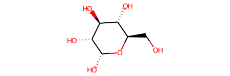

```python
# given the SMILES of alpha-D-glucose, return all stereoisomers

from rdkit.Chem import MolFromSmiles

alpha_d_glucose = 'O[C@@H]1[C@H](O)[C@@H](O)[C@H](O)[C@@H](CO)O1'

MolFromSmiles(alpha_d_glucose)
```

```python
from itertools import product, zip_longest

def all_stereoisomers(smiles):
    '''Given an SMILES string, return list of SMILES string of all stereoisomers'''
    # convert smiles to a list of substrings separated by occurance of stereogenic centers
    split_smiles = smiles.split('@@')
    split_smiles = [frag.split('@') for frag in split_smiles]
    # flatten list of lists to list
    split_smiles = [substring for sublist in split_smiles for substring in sublist]
    num_stereogenic_centers = len(split_smiles) - 1
    # obtain all combinations of configurations
    configurations = product(['@@', '@'], repeat = num_stereogenic_centers)
    # for each combinations of configurations, write the SMILES of the stereoisomer
    isomers = []
    for config in configurations:
        stereoisomer = ''
        for frag_config in zip_longest(split_smiles, config, fillvalue=''):
            stereoisomer += ''.join(frag_config)
        isomers.append(stereoisomer)
    return isomers

hexose_isomers = all_stereoisomers(alpha_d_glucose)
len(hexose_isomers)
```

```
32
```

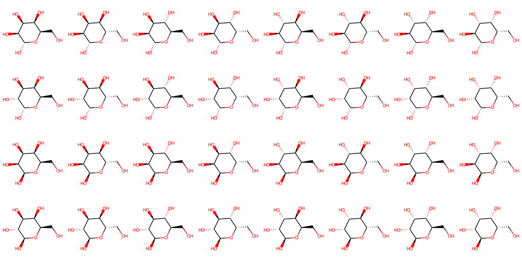

```python
from rdkit.Chem.Draw import MolsToGridImage

mols = [MolFromSmiles(smiles) for smiles in hexose_isomers]
MolsToGridImage(mols, molsPerRow = 8)
```

# Learning to Code as an Experimental Chemist

- Coding is another tool
- Enforce findings through theoretical calculations
- Target and expedite investigation
- Codify and automate analysis

# Automate/Expedite Analysis of Experimental Measurements

[output not shown]

```python
# Suppose you are tasked with assigning peaks measured by COSY spectrum to the known structure, N-acetylcadaverine.
unique_shifts = {'A': 1.48, 'B': 1.58, 'C': 1.85, 'D': 2.63, 'E': 3.15}
cross_peaks = [('A', 'B'), ('A', 'D'), ('B', 'E')]
```

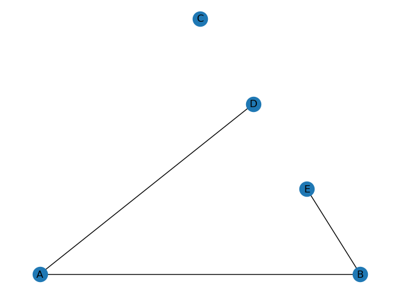

```python
import networkx as nx

g = nx.Graph()
g.add_nodes_from(unique_shifts)
g.add_edges_from(cross_peaks)
nx.draw_planar(g, with_labels=True)
```